# Homework 2 - Answer Key

Vicki Hertzberg and Melinda Higgins

2/14/2018

# *Due Date* is 21 February 2018

This homework is meant to further your `dplyr` and `ggplot2` skills.

First, install the package

- `car`

## Installing the `car` package

We found some hiccups when we were designing this homework. With a little sleuthing, we were able to figure out that some of the issues related to installing the package and dependent package called `quantreg`. So before you install `car` use the following R commands:

- install.packages(“quantreg”, dependencies=TRUE)
- install.packages(“car”, dependencies=TRUE)

You might get this question in the console:

“Do you want to install from sources the package which needs compilation” followed by a prompt for you to respond yes or no, which looks like

`y/n:`

Usually when you see this prompt in RStudio, `y` is a good default response. However when installing `quantreg` and `car`, we found that if you answered `n` to the prompts, all will work well. *(answering `y` here leads to other issues you can avoid for now… we don’t want you to descend into R purgatory, LOL)*

```r
# load packages car and tidyverse
# which loads dplyr and ggplot2
library(car)
library(tidyverse)
```

## The Data - `Davis` dataset in the `car` package

The `Davis` dataset in the `car` package contains data on the measured and reported heights and weights of men and women engagedin regular exercise. *[For more information, type `?car::Davis` in the Console to bring up the HELP pages on the `Davis` dataset in the `car` package.]*

Use tools within the `dplyr` package as much as possible to answer the following questions.

##### **Question 1:** What kind of R object is the `Davis` dataset?

```r
class(car::Davis)
```

```
## [1] "data.frame"
```

##### **Question 2:** How many observations are in the `Davis` dataset?

```r
# base r approach
dim(car::Davis)
```

```
## [1] 200   5
```

```r
# dplyr approach
car::Davis %>%
  summarise(n = n())
```

```
##     n
## 1 200
```

##### **Question 3:** For reported weight, how many observations have a missing value?

```r
# base r approach
summary(car::Davis$repwt)
```

```
##    Min. 1st Qu.  Median    Mean 3rd Qu.    Max.    NA's
##   41.00   55.00   63.00   65.62   73.50  124.00      17
```

```r
# dplyr approach
# this is challenging
car::Davis %>%
  summarise_all(funs(sum(is.na(.))))
```

```
##   sex weight height repwt repht
## 1   0      0      0    17    17
```

```r
# purrr approach
# not covered in class yet
car::Davis %>% map(~ sum(is.na(.)))
```

```
## $sex
## [1] 0
##
## $weight
## [1] 0
##
## $height
## [1] 0
##
## $repwt
## [1] 17
##
## $repht
## [1] 17
```

##### **Question 4:** How many observations have no missing values? *(HINT: find complete cases)*

```r
# Base r approach
nomiss <- complete.cases(car::Davis)
sum(nomiss)
```

```
## [1] 181
```

```r
# dplyr approach
davisComplete <-  car::Davis %>%
  filter(complete.cases(.))

davisComplete %>%
  summarise(n = n())
```

```
##     n
## 1 181
```

```r
# all together - dplyr approach
car::Davis %>%
  filter(complete.cases(.)) %>%
  summarise(n = n())
```

```
##     n
## 1 181
```

Create a subset containing only females.

##### **Question 5:** How many females are in this subset?

```r
# dplyr approach
davisFonly <- car::Davis %>%
  filter(sex == "F")

davisFonly %>%
  summarise(n = n())
```

```
##     n
## 1 112
```

```r
# base r approach to get number F and M
table(car::Davis$sex)
```

```
##
##   F   M
## 112  88
```

```r
summary(car::Davis$sex)
```

```
##   F   M
## 112  88
```

That last question was an opportunity for you to show-off your `dplyr` confidence.

*Now* return to the overall dataset with both males and females.

Body mass index is one way to quantify the amount of tissue mass (muscle, fat, and bone) in an individual, then categorize that person as *underweight*, *normal* *weight*, *overweight*, or *obese* according to that value.

We calculate the BMI as the **ratio of the weight in kilograms divided by the square of the height in meters**, and the categorization based on BMI is as follows:

### BMI Categories

| Category | BMI range (kg/m2) |
| --- | --- |
| Underweight | <18.5 |
| Normal | 18.5 to <25 |
| Overweight | 25 to <30 |
| Obese | 30 or higher |

Create the BMI variable and then a variable to depict BMI category. Note that the `height` variable is in centimeters, and `weight` is in kg. You need to create the BMI variable using the correct formula.

Now answer these questions:

##### **Question 6:** What is the average BMI for these individuals?

```r
# dplyr approach to compute bmi
Davis <- car::Davis %>%
  mutate(bmi = weight/(height/100)^2)

# dplyr approach to get mean bmi
Davis %>%
  summarise(meanbmi = mean(bmi))
```

```
##    meanbmi
## 1 24.70096
```

```r
# base r approach
mean(Davis$bmi)
```

```
## [1] 24.70096
```

##### **Question 7:** How do these individuals fall into the BMI categories (what are the frequencies and relative %’s)?

```r
# dplyr approach for recoding
# using mutate() and if_else() functions
Davis <- Davis %>%
  mutate(bmicat = if_else(bmi<18.5,
                        "1. underweight",
                        if_else(bmi<25,
                                "2. normal",
                                if_else(bmi<30,
                                        "3. overweight",
                                        "4. obese",
                                        "missing"),
                                "missing"),
                        "missing"))

# dplyr approach to get counts
# of bmi categories
Davis %>%
  count(bmicat)
```

```
## # A tibble: 4 x 2
##   bmicat             n
##   <chr>          <int>
## 1 1. underweight    18
## 2 2. normal        143
## 3 3. overweight     35
## 4 4. obese           4
```

```r
# base r approach for counts
table(Davis$bmicat)
```

```
##
## 1. underweight      2. normal  3. overweight       4. obese
##             18            143             35              4
```

```r
summary(as.factor(Davis$bmicat))
```

```
## 1. underweight      2. normal  3. overweight       4. obese
##             18            143             35              4
```

```r
# optional - alternate ways to get
# frequency summary tables
# this uses the gmodels package
library(gmodels)
gmodels::CrossTable(x=Davis$bmicat, y=Davis$sex)
```

```
##
##
##    Cell Contents
## |-------------------------|
## |                       N |
## | Chi-square contribution |
## |           N / Row Total |
## |           N / Col Total |
## |         N / Table Total |
## |-------------------------|
##
##
## Total Observations in Table:  200
##
##
##                | Davis$sex
##   Davis$bmicat |         F |         M | Row Total |
## ---------------|-----------|-----------|-----------|
## 1. underweight |        17 |         1 |        18 |
##                |     4.751 |     6.046 |           |
##                |     0.944 |     0.056 |     0.090 |
##                |     0.152 |     0.011 |           |
##                |     0.085 |     0.005 |           |
## ---------------|-----------|-----------|-----------|
##      2. normal |        90 |        53 |       143 |
##                |     1.229 |     1.564 |           |
##                |     0.629 |     0.371 |     0.715 |
##                |     0.804 |     0.602 |           |
##                |     0.450 |     0.265 |           |
## ---------------|-----------|-----------|-----------|
##  3. overweight |         4 |        31 |        35 |
##                |    12.416 |    15.803 |           |
##                |     0.114 |     0.886 |     0.175 |
##                |     0.036 |     0.352 |           |
##                |     0.020 |     0.155 |           |
## ---------------|-----------|-----------|-----------|
##       4. obese |         1 |         3 |         4 |
##                |     0.686 |     0.874 |           |
##                |     0.250 |     0.750 |     0.020 |
##                |     0.009 |     0.034 |           |
##                |     0.005 |     0.015 |           |
## ---------------|-----------|-----------|-----------|
##   Column Total |       112 |        88 |       200 |
##                |     0.560 |     0.440 |           |
## ---------------|-----------|-----------|-----------|
##
##
```

```r
# optional - a nice way to get a formatted
# table of the counts for bmi categories
library(janitor)
Davis %>%
  janitor::tabyl(bmicat)
```

```
##           bmicat   n percent
## 1 1. underweight  18   0.090
## 2      2. normal 143   0.715
## 3  3. overweight  35   0.175
## 4       4. obese   4   0.020
```

```r
# keep the janitor::tabyl output
# and make a table using knitr::kable()
t1 <- Davis %>%
  janitor::tabyl(bmicat)

knitr::kable(t1)
```

| bmicat | n | percent |
| --- | --- | --- |
| 1. underweight | 18 | 0.090 |
| 2. normal | 143 | 0.715 |
| 3. overweight | 35 | 0.175 |
| 4. obese | 4 | 0.020 |

## Test your graphing skills using `ggplot2`

Using the `Davis` dataset from the `car` package, create the following graphics/figures using `ggplot()` and associated `geom_xxx()` functions.

##### **Question 8:** Create a histogram of BMI.

*What do you notice about the distribution (any outliers or skewness)?*

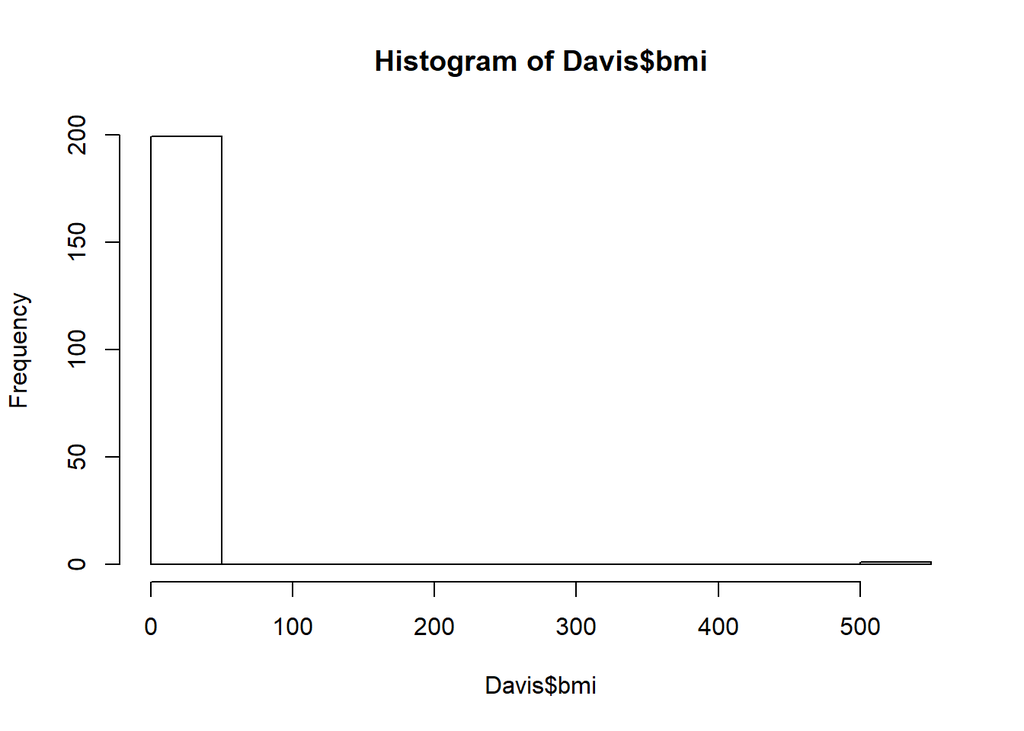

```r
# base r
hist(Davis$bmi)
```

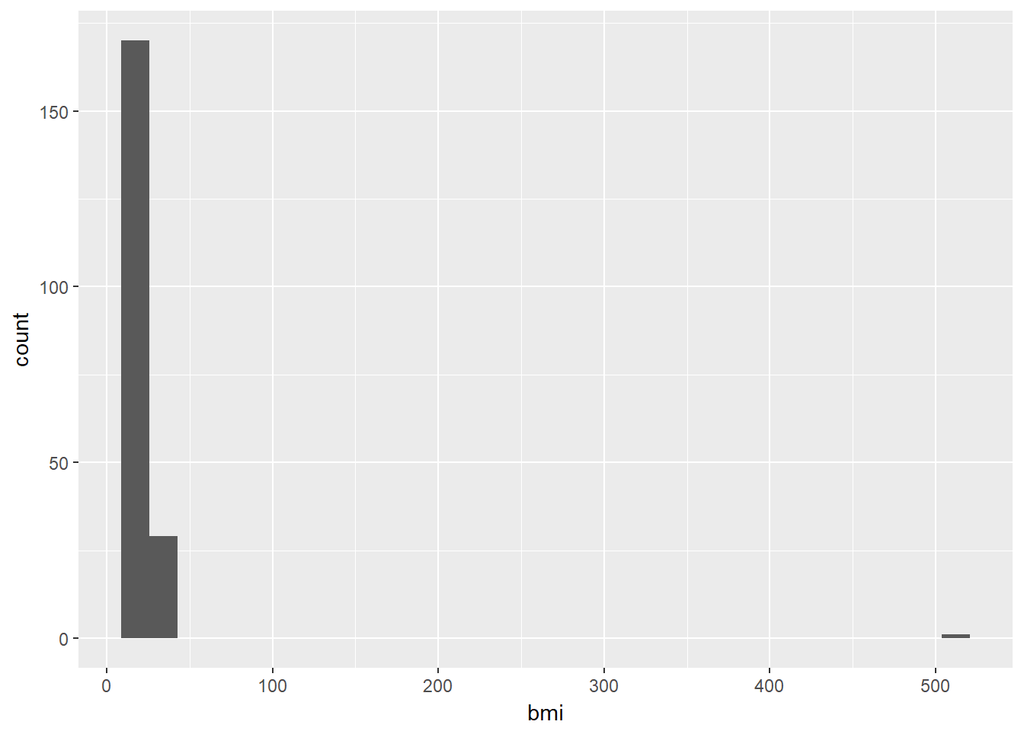

```r
# dplyr approach
ggplot(Davis, aes(bmi)) +
  geom_histogram()
```

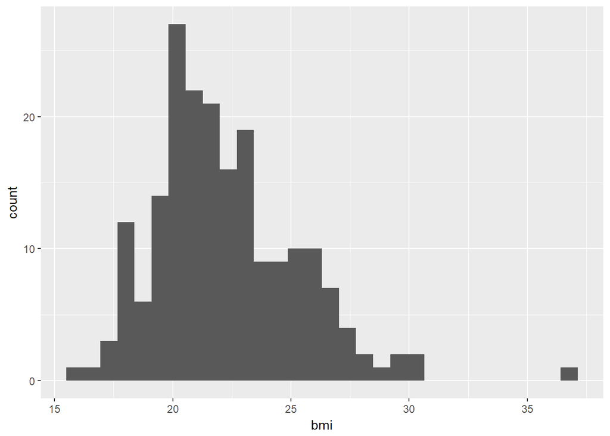

```r
# there is an outlier - update plot or
# data to exclude outlier in plot

Davis2 <- Davis %>%
  filter(bmi < 100)

ggplot(Davis2, aes(bmi)) +
  geom_histogram()
```

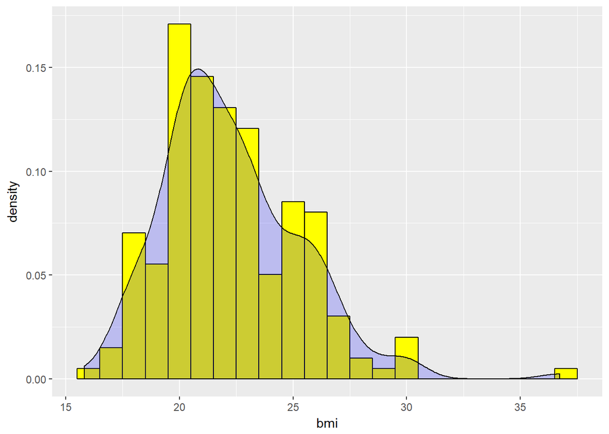

```r
# add density curve overlay to histogram
Davis2 %>%
  ggplot(aes(bmi)) +
  geom_histogram(aes(y=..density..),
                 colour="black",fill="yellow",
                 binwidth=1) +
  geom_density(alpha=.2, fill="blue")
```

##### **Question 9:** Create side-by-side boxplots of the BMI distributions by gender

*Remember to remove any outliers if needed*

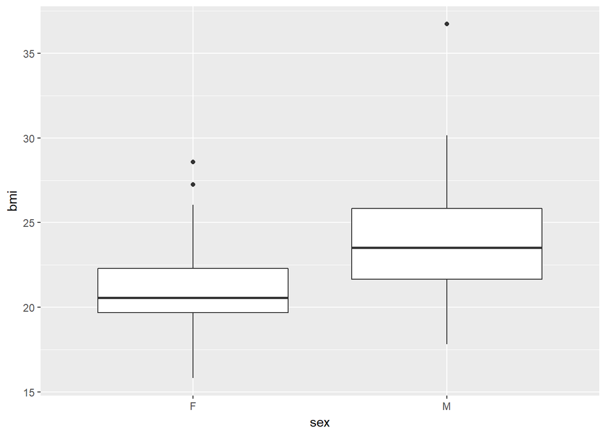

```r
# boxplots of bmi by gender
Davis2 %>% ggplot(aes(x=sex, y=bmi)) +
  geom_boxplot()
```

##### **Question 10:** Create a clustered bar chart of the BMI categories by gender

*(note: the y-axis should be counts)*

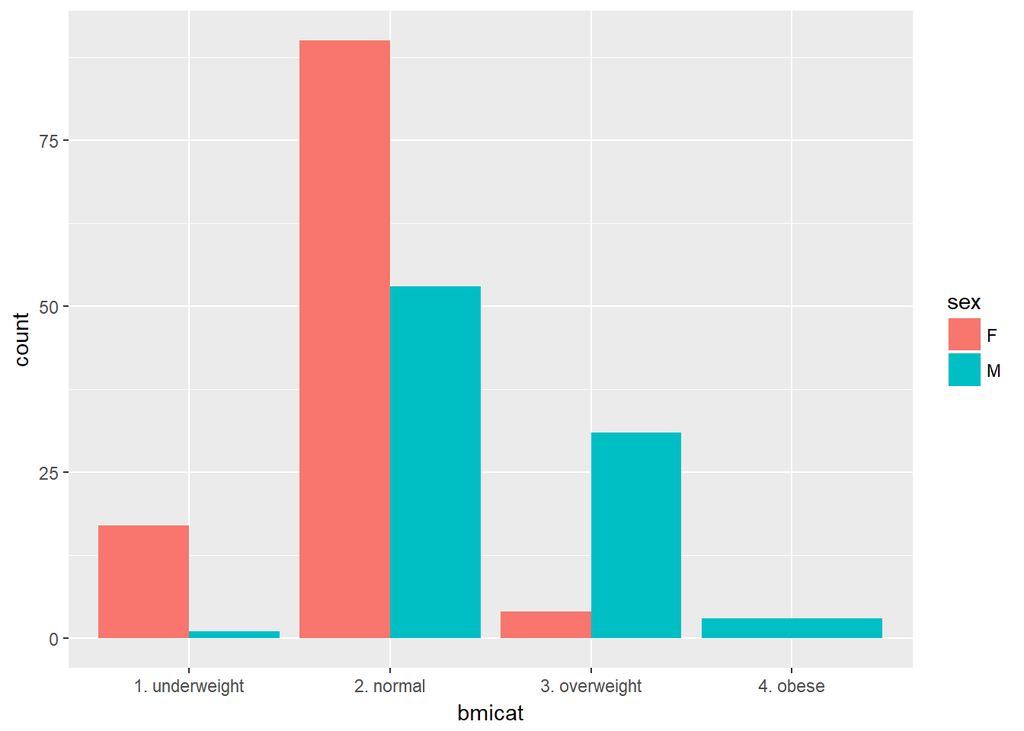

```r
# cluster barchart of bmi categories by gender
Davis2 %>% ggplot(aes(x=bmicat, fill=sex)) +
  geom_bar(position = "dodge")
```